# Data Visualization

Ziyuan Huang

Last Updated: 2025-12-11

# Programming Suggestion

- We will be using `ggplot2` to create our data visualizations.
- The code can get very long, so you should use code stacking!
- Stacking your code can help you troubleshoot and see what is going on easier.

```r
textline +
  stat_summary(fun = mean,
               geom = "point") +
  stat_summary(fun = mean,
               geom = "line",
               aes(group = Group)) +
  stat_summary(fun.data = mean_cl_normal,
               geom = "errorbar",
               width = .2) +
  xlab("Measurement Time") +
  ylab("Mean Grammar Score") +
  cleanup +
  scale_color_manual(name = "Texting Option",
                     labels = c("All the texts", "None of the texts"),
                     values = c("Black", "Grey")) +
  scale_x_discrete(labels = c("Baseline", "Six Months"))
```

# Outline

- Reminder how to import files
- Two key issues for data format: factors, format
- Graphs:
  - Histograms
  - Scatterplots
  - Bar Graphs
  - Line Graphs

# Working with Files

- Let’s load SPSS file “ChickFlick.sav”.
- Note that I have this saved in a `data` folder that is in the same folder as my Markdown file.
- Remember that the `rio` library can usually interpret these files without much work using the `import()` function.

```r
library(rio)
chickflick <- import("data/ChickFlick.sav")
str(chickflick)
```

```
## 'data.frame':    40 obs. of  3 variables:
##  $ gender : num  1 1 1 1 1 1 1 1 1 1 ...
##   ..- attr(*, "label")= chr "Gender of Participant"
##   ..- attr(*, "format.spss")= chr "F8.0"
##   ..- attr(*, "labels")= Named num [1:2] 1 2
##   .. ..- attr(*, "names")= chr [1:2] "Male" "Female"
##  $ film   : num  1 1 1 1 1 1 1 1 1 1 ...
##   ..- attr(*, "label")= chr "Name of Film"
##   ..- attr(*, "format.spss")= chr "F8.0"
##   ..- attr(*, "display_width")= int 18
##   ..- attr(*, "labels")= Named num [1:2] 1 2
##   .. ..- attr(*, "names")= chr [1:2] "Bridget Jones's Diary" "Memento"
##  $ arousal: num  22 13 16 10 18 24 13 14 19 23 ...
##   ..- attr(*, "label")= chr "Psychological Arousal During the Film"
##   ..- attr(*, "format.spss")= chr "F8.0"
```

# Factor Categorical Variables

- We saw on the previous slide that the `gender` and `film` variables have embedded data from SPSS.
- However, this does not translate to a factor variable, which is useful for making plots.

```r
table(chickflick$gender)
```

```
##
##  1  2
## 20 20
```

```r
table(chickflick$film)
```

```
##
##  1  2
## 20 20
```

# How to Factor

```r
chickflick$gender <- factor(chickflick$gender, #the variable you want to factor
                            levels = c(1,2), #the information already in the data
                            labels = c("Male", "Female")) #the labels for those levels

table(chickflick$gender)
```

```
##
##   Male Female
##     20     20
```

# Data Structure Format

- **Wide** datasets: rows are *participants*, and columns are variables.
  - Each participant gets one row, while each variable gets one column.
- **Long** datasets: rows are *assessments*, and columns are variables.
  - Each time point or repeated assessment gets a separate row, while each column still represents a variable.

# Rearrange Data: Wide to Long

```r
library(reshape) #note: modern alternative is tidyr::pivot_longer()
cricket <- import("data/Jiminy Cricket.csv")
head(cricket)
```

```
##   ID Strategy Success_Pre Success_Post
## 1  1        1          53           74
## 2  2        1          62           67
## 3  3        1          52           33
## 4  4        1          57           62
## 5  5        1          55           44
## 6  6        1          52           65
```

# Rearrange Data: Wide to Long

- `id = c("column", "column")` - constant variables you do not want to change. These will stay their own column but get repeated when necessary.
- `measured = c("column", "column")` - dependent variables you want to combine into one column.

```r
longcricket <- melt(cricket,  #name of dataset
                    id = c("ID", "Strategy"),
                    measured = c("Success_Pre", "Success_Post"))
#you can actually leave measured blank
head(longcricket)
```

```
##   ID Strategy    variable value
## 1  1        1 Success_Pre    53
## 2  2        1 Success_Pre    62
## 3  3        1 Success_Pre    52
## 4  4        1 Success_Pre    57
## 5  5        1 Success_Pre    55
## 6  6        1 Success_Pre    52
```

# Rearrange Data: Wide to Long

- Unfortunately, our melted columns become `variable` and `value`, which are not very useful names.
- We should rename them for clarity!

```r
colnames(longcricket)[3:4] #just to figure out which ones
```

```
## [1] "variable" "value"
```

```r
colnames(longcricket)[3:4] <- c("Time", "Score")
```

# The Art of Presenting Data

- Graphs should (Tufte, 2001):
  - Show the data.
  - Induce the reader to think about the data being presented (rather than some other aspect of the graph).
  - Avoid distorting the data.
  - Present many numbers with minimum ink.
  - Make large data sets (assuming you have one) coherent.
  - Encourage the reader to compare different pieces of data.
  - Reveal data.

# Why is this Graph Bad?

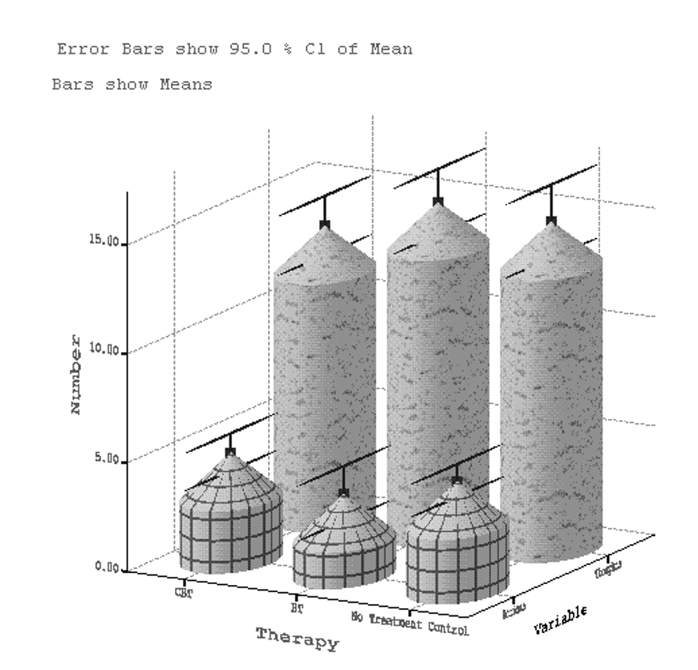

# Other Bad Design Choices

- 3D charts need to be well-made (check out `plotly`).
- Patterns *(depending)*
- Cylindrical bars
- Bad axis labels
- Overlays

# Why is this Graph Better?

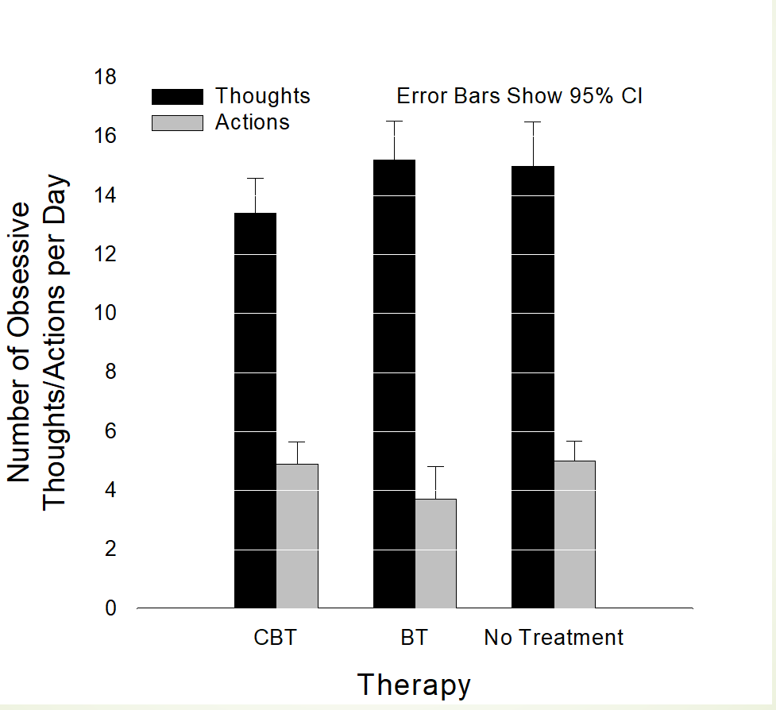

# Do Not Deceive the Reader!

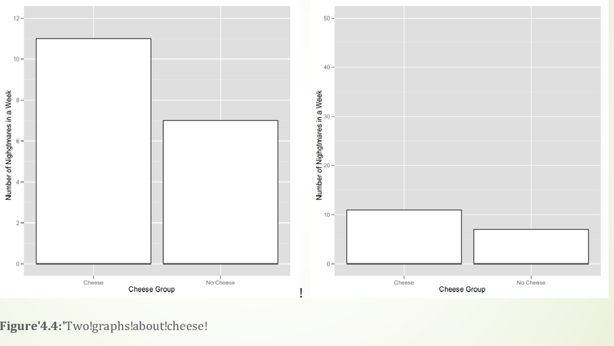

# Plotting in R

- The great thing about `ggplot2` is that it is very flexible and well documented!
- The bad thing about `ggplot2` is that there’s a lot going on.
- You will need `Hmisc` for confidence interval error bars.

```r
library(ggplot2)
library(Hmisc)
```

# Working with ggplot2

- How ggplot works: First you define the basic structure of a plot you want.

```r
#an example
myGraph <- ggplot(dataset,
                  aes(x_axis, y_axis,
                      color = legend_var,
                      fill = legend_var))
```

# Working with ggplot2

- Now we have myGraph saved with all the variables, but no visualization.
- Next, you can add options to create new layers on the graph.

```r
#an example part 2
myGraph +
  geom_bar() +
  geom_point() +
  xlab("X Axis Label") +
  ylab("Y Axis Label")
```

# Histograms

- Histograms plot:
  - The continuous score (x-axis)
  - The frequency (y-axis)
- Histograms help us to identify:
  - The shape of the distribution. Measured using **Skew, Kurtosis, or the Spread or variation in scores.**
- Unusual scores

# Histogram: Example

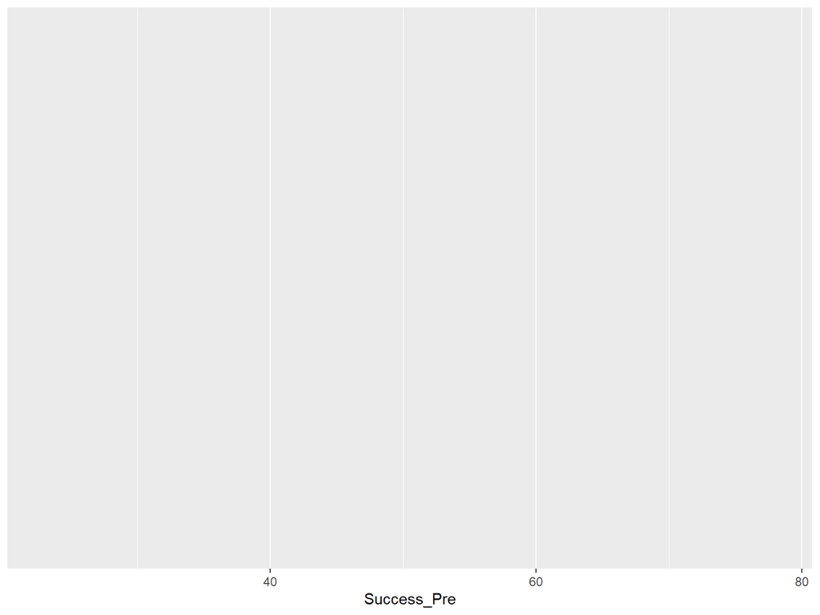

```r
crickethist <- ggplot(data = cricket, #dataset
                      aes(x = Success_Pre) #only define X axis
                      )
crickethist
```

# Histogram: Example

- Our current plot is blank, let’s add the histogram bars:

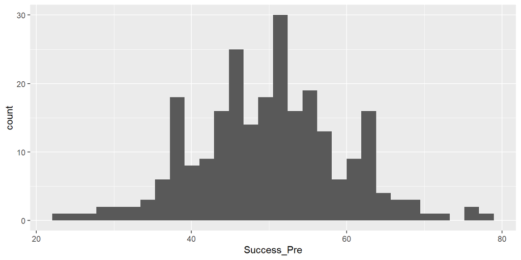

```r
crickethist +
  geom_histogram()
```

# Histogram: Example

- Make the bins different:

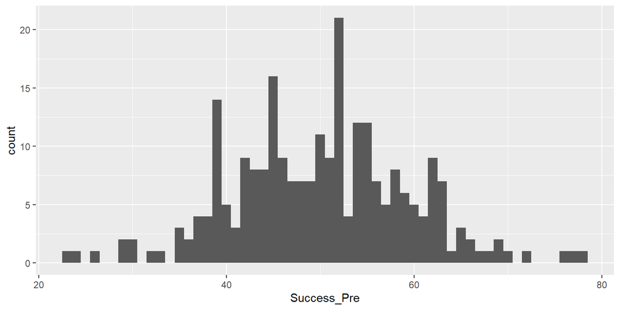

```r
crickethist +
  geom_histogram(binwidth = 1)
```

# Histogram: Example

- You can change the color:
  - Color is the outline of the bars
  - Fill is the interior of the bars

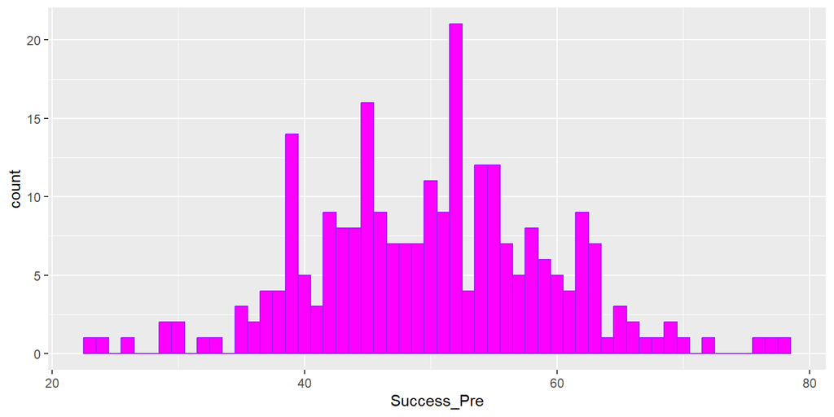

```r
crickethist +
  geom_histogram(binwidth = 1, color = 'purple', fill = 'magenta')
```

# Histogram: Example

- Let’s add some labels:

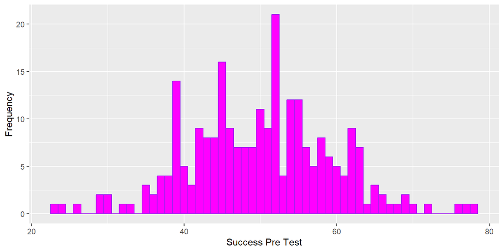

```r
crickethist +
  geom_histogram(binwidth = 1, color = 'purple', fill = 'magenta') +
  xlab("Success Pre Test") +
  ylab("Frequency")
```

# Histogram: Example 2

- This dataset includes festival attendees who indicated their hygiene score on each day of the festival from 0 (eau de toilet) to 4 (eau de toilette)

```r
festival <- import("data/festival.csv")
str(festival)
```

```
## 'data.frame':    810 obs. of  5 variables:
##  $ ticknumb: int  2111 2229 2338 2384 2401 2405 2467 2478 2490 2504 ...
##  $ gender  : chr  "Male" "Female" "Male" "Female" ...
##  $ day1    : num  2.64 0.97 0.84 3.03 0.88 0.85 1.56 3.02 2.29 1.11 ...
##  $ day2    : num  1.35 1.41 NA NA 0.08 NA NA NA NA 0.44 ...
##  $ day3    : num  1.61 0.29 NA NA NA NA NA NA NA 0.55 ...
```

# Histogram: Example 2

- In the previous example, we added things one at a time just as an example
- You can run the whole graph at once!
- Create the plot object:

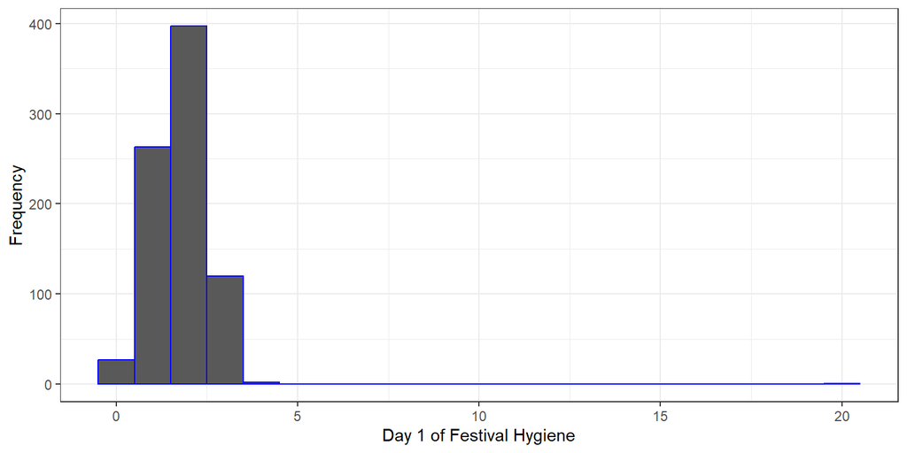

```r
festivalhist <- ggplot(data = festival, aes(x = day1))
festivalhist +
  geom_histogram(binwidth = 1, color = 'blue') +
  xlab("Day 1 of Festival Hygiene") +
  ylab("Frequency") +
  theme_bw() #theme_classic() also good!
```

# Focus on these Facets

- All graphs should have:
  - X and Y axis labels.
  - The use of titles depends on where the graph is used.
  - Labels for the legend, facets, other group markers.
  - Error bars when appropriate.
  - Readable/cleaned up!

# Clean Up?

- `theme_bw()` and `theme_classic()` are great, easy themes to make graphs presentable.
- Another important facet may be the font size, as it appears to be pretty small on the default.
- Additionally, we will want to eliminate that default gray background that is included with legends.

```r
cleanup <- theme(panel.grid.major = element_blank(), #no grid lines
                panel.grid.minor = element_blank(), #no grid lines
                panel.background = element_blank(), #no background
                axis.line.x = element_line(color = 'black'), #black x axis line
                axis.line.y = element_line(color = 'black'), #black y axis line
                legend.key = element_rect(fill = 'white'), #no legend background
                text = element_text(size = 15)) #bigger text size
```

# Clean Up?

- Save that code and then you can just do graph + cleanup.

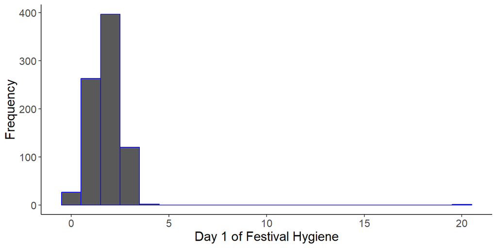

```r
festivalhist +
  geom_histogram(binwidth = 1, color = 'blue') +
  xlab("Day 1 of Festival Hygiene") +
  ylab("Frequency") +
  cleanup
```

# Scatterplots

- Simple scatter: X and Y are continuous variables
- Grouped scatter: X and Y are continuous variables with legend for a third variable (generally categorical).

# Scatterplots: Example

- Anxiety and Exam Performance: 103 students who rated their exam anxiety, time spent revising their exam, exam performance, and gender.

```r
exam <- import("data/Exam Anxiety.csv")
str(exam)
```

```
## 'data.frame':    103 obs. of  5 variables:
##  $ Code   : int  1 2 3 4 5 6 7 8 9 10 ...
##  $ Revise : int  4 11 27 53 4 22 16 21 25 18 ...
##  $ Exam   : int  40 65 80 80 40 70 20 55 50 40 ...
##  $ Anxiety: num  86.3 88.7 70.2 61.3 89.5 ...
##  $ Gender : int  1 2 1 1 1 2 2 2 2 2 ...
```

# Scatterplots: Example

- Gender is currently a continuous variable, so we should factor that variable to appropriately label it on a graph when used.

```r
table(exam$Gender)
```

```
##
##  1  2
## 52 51
```

```r
exam$Gender <- factor(exam$Gender,
                     levels = c(1,2),
                     labels = c("Male", "Female"))
table(exam$Gender)
```

```
##
##   Male Female
##     52     51
```

# Simple Scatterplot

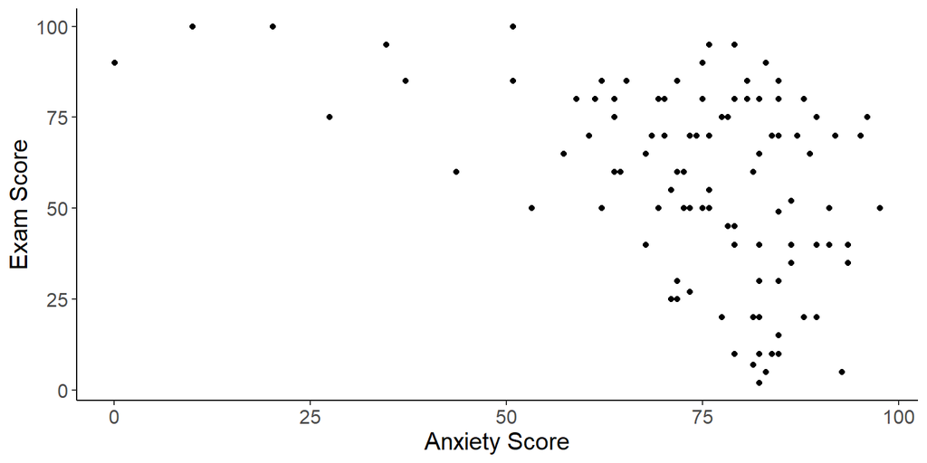

```r
scatter <- ggplot(exam, aes(Anxiety, Exam))
scatter +
  geom_point() +
  xlab("Anxiety Score") +
  ylab("Exam Score") +
  cleanup
```

# Simple Scatterplot with Regression Line

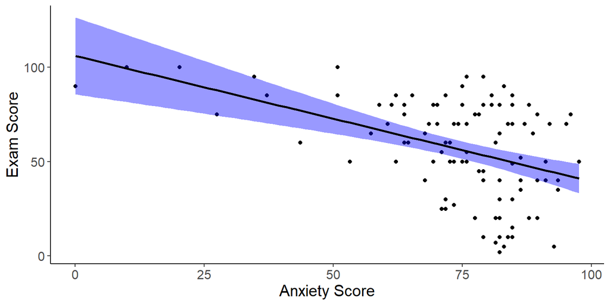

```r
scatter +
  geom_point() +
  geom_smooth(method = 'lm', formula = y ~ x,
              color = 'black', fill = 'blue') +
  xlab('Anxiety Score') +
  ylab('Exam Score') +
  cleanup
```

# Grouped Scatterplot

- How to control the colors and fill with legends.
  - scale_fill_manual(name, labels, values)
  - scale_color_manual(name, labels, values)

# Grouped Scatterplot with Regression Line

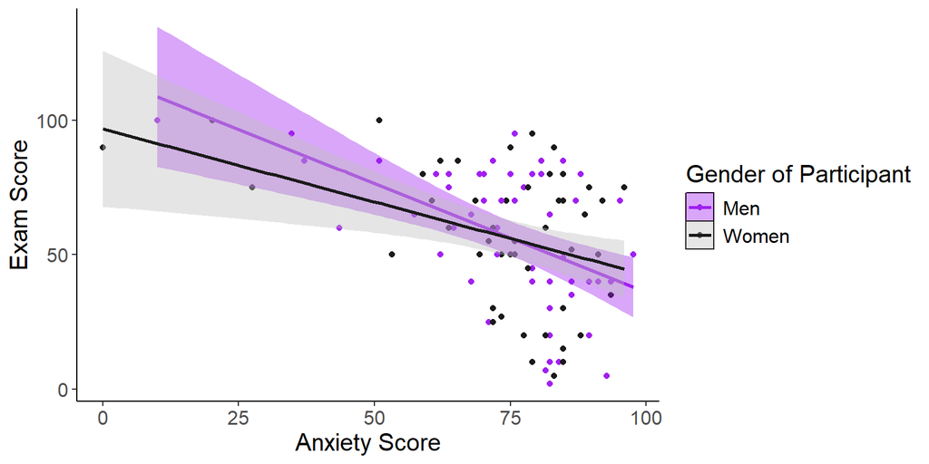

```r
scatter2 <- ggplot(exam, aes(Anxiety, Exam,
                             color = Gender, fill = Gender)) #why both?
scatter2 +
  geom_point() +
  geom_smooth(method = "lm", formula = y ~ x) +
  xlab("Anxiety Score") +
  ylab("Exam Score") +
  cleanup +
  scale_fill_manual(name = "Gender of Participant",
                    labels = c("Men", "Women"),
                    values = c("purple", "grey")) +
  scale_color_manual(name = "Gender of Participant",
                     labels = c("Men", "Women"),
                     values = c("purple", "grey10"))
```

# `GGally` for Multiple Visualization

- `GGally` has a plotting function that uses `ggplot2` as a back end.
- The function `ggpairs` allows you to create a scatterplot matrix for any numerical variables in a dataset.

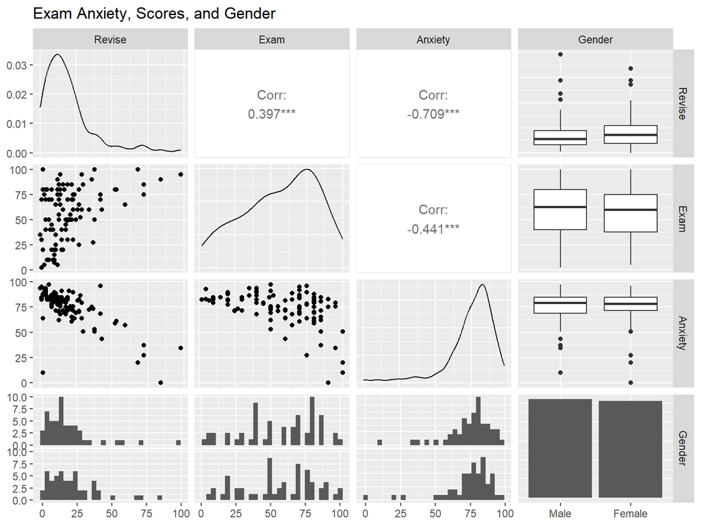

```r
library(GGally)
ggpairs(data = exam[ , -1], #no participant variable
        title = "Exam Anxiety, Scores, and Gender")
```

# Bar Graphs

- Bar graphs are often used to display mean scores to allow comparison between groups.
- Error bars can be added to display the precision of the mean:
  - The confidence interval
  - The standard deviation
  - The standard error

# Bar Graph: One Independent Variable

- Is there such a thing as a ‘chick flick’?
  - Twenty men and twenty women were assigned to watch one of two movies: A ‘chick flick’ (Bridget Jones’s Diary) or the control movie (Memento).
  - Physiological arousal was used as an indicator of how much they enjoyed the film.

# Bar Chart: One Independent Variable

- Be sure to convert all factor variables, otherwise they will be treated as continuous (or you’ll get strange errors!).

```r
str(chickflick) #already fixed gender
```

```
## 'data.frame':    40 obs. of  3 variables:
##  $ gender : Factor w/ 2 levels "Male","Female": 1 1 1 1 1 1 1 1 1 1 ...
##  $ film   : num  1 1 1 1 1 1 1 1 1 1 ...
##   ..- attr(*, "label")= chr "Name of Film"
##   ..- attr(*, "format.spss")= chr "F8.0"
##   ..- attr(*, "display_width")= int 18
##   ..- attr(*, "labels")= Named num [1:2] 1 2
##   .. ..- attr(*, "names")= chr [1:2] "Bridget Jones's Diary" "Memento"
##  $ arousal: num  22 13 16 10 18 24 13 14 19 23 ...
##   ..- attr(*, "label")= chr "Psychological Arousal During the Film"
##   ..- attr(*, "format.spss")= chr "F8.0"
```

```r
chickflick$film <- factor(chickflick$film,
                    levels = c(1,2),
                    labels = c("Bridget Jones", "Memento"))
```

# Bar Chart: One Independent Variable Example

- To add the mean, displayed as bars, we can add this as a layer to bar using the `stat_summary()` function:

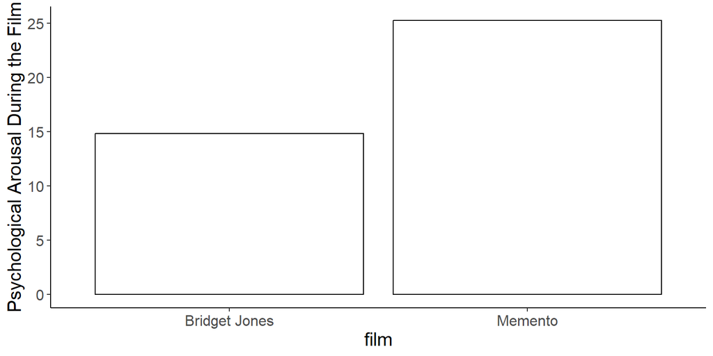

```r
chickbar <- ggplot(chickflick, aes(film, arousal))
chickbar +
  stat_summary(fun = mean,
               geom = "bar",
               fill = "White",
               color = "Black") +
  cleanup
```

# Bar Chart: One Independent Variable Example

- To add error bars, add these as a layer using `stat_summary()`:

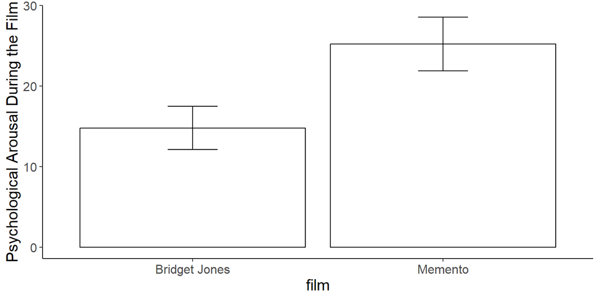

```r
chickbar +
  stat_summary(fun = mean,
               geom = "bar",
               fill = "White",
               color = "Black") +
  stat_summary(fun.data = mean_cl_normal,
               geom = "errorbar",
               position = position_dodge(width = 0.90),
               width = 0.2) +
  cleanup
```

# Bar Chart: One Independent Variable Example

- Now, add the rest of things we’ve been doing:

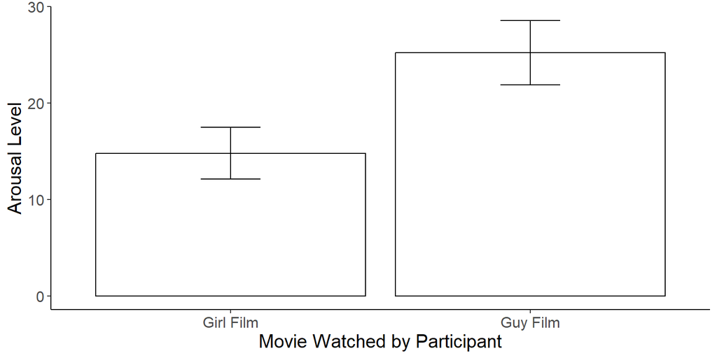

```r
chickbar +
  stat_summary(fun = mean,
               geom = "bar",
               fill = "White",
               color = "Black") +
  stat_summary(fun.data = mean_cl_normal,
               geom = "errorbar",
               position = position_dodge(width = 0.90),
               width = 0.2) +
  xlab("Movie Watched by Participant") +
  ylab("Arousal Level") +
  cleanup +
  scale_x_discrete(labels = c("Girl Film", "Guy Film"))
```

# Bar Chart: Two Independent Variables

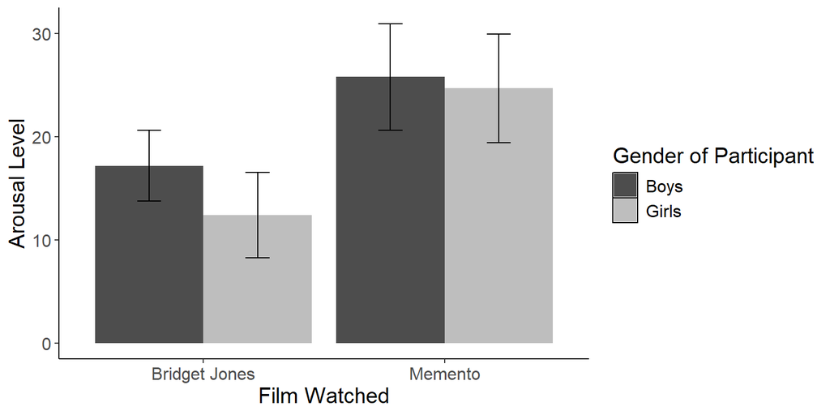

```r
chickbar2 <- ggplot(chickflick, aes(film, arousal, fill = gender))
chickbar2 +
  stat_summary(fun = mean,
               geom = "bar",
               position = "dodge") +
  stat_summary(fun.data = mean_cl_normal,
               geom = "errorbar",
               position = position_dodge(width = 0.90),
               width = .2) +
  xlab("Film Watched") +
  ylab("Arousal Level") +
  cleanup +
  scale_fill_manual(name = "Gender of Participant",
                    labels = c("Boys", "Girls"),
                    values = c("Gray30", "Gray"))
```

# Line Graphs

- When to use a line graph:
  - With data that X is categorical, but is considered “mildly continuous”
  - Usually with repeated measures data over time
  - The example here is not quite appropriate for a line graph but does include repeated measures data for practicing restructuring data.

# Line Graphs: One Independent Variable

- How to cure hiccups? Participants included 15 participants who tried four hiccup cures.
- The dependent variable included the number of hiccups in the minute after each procedure.

```r
hiccups <- import("data/Hiccups.csv")
str(hiccups)
```

```
## 'data.frame':    15 obs. of  4 variables:
##  $ Baseline: int  15 13 9 7 11 14 20 9 17 19 ...
##  $ Tongue  : int  9 18 17 15 18 8 3 16 10 10 ...
##  $ Carotid : int  7 7 5 10 7 10 7 12 9 8 ...
##  $ Other   : int  2 4 4 5 4 3 3 3 4 4 ...
```

# Line Graphs: One Independent Variable

- These data are in the wrong format for `ggplot2` to use.
- We need all of the scores stacked up in a single column and then another variable that specifies the type of intervention.

```r
longhiccups <- melt(hiccups,
                    measured = c("Baseline", "Tongue", "Carotid", "Other"))
str(longhiccups)
```

```
## 'data.frame':    60 obs. of  2 variables:
##  $ variable: Factor w/ 4 levels "Baseline","Tongue",..: 1 1 1 1 1 1 1 1 1 1 ...
##  $ value   : int  15 13 9 7 11 14 20 9 17 19 ...
```

```r
colnames(longhiccups) <- c("Intervention", "Hiccups")
```

# Line Graphs: One Independent Variable

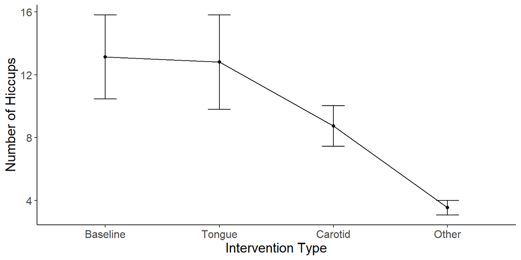

```r
hiccupline <- ggplot(longhiccups, aes(Intervention, Hiccups))
hiccupline +
  stat_summary(fun = mean, ##adds the points
               geom = "point") +
  stat_summary(fun = mean, ##adds the line
               geom = "line",
               aes(group=1)) + ##necessary for mapping line to dots
  stat_summary(fun.data = mean_cl_normal, ##adds the error bars
               geom = "errorbar",
               width = .2) +
  xlab("Intervention Type") +
  ylab("Number of Hiccups") +
  cleanup
```

# Line Graphs: Two Independent Variables

- Is text-messaging bad for your grammar? Participants included 50 children who were split into two groups (between-subjects): text-messaging allowed or text-messaging forbidden.
- In a second variable (repeated measures), each child was measured at two points in time: at baseline and six months later.
- The dependent variable was the percent correct score on a grammar test.

# Line Graphs: Two Independent Variables

```r
texting <- import("data/Texting.xlsx")
str(texting)
```

```
## 'data.frame':    50 obs. of  3 variables:
##  $ Group     : num  1 1 1 1 1 1 1 1 1 1 ...
##  $ Baseline  : num  52 68 85 47 73 57 63 50 66 60 ...
##  $ Six_months: num  32 48 62 16 63 53 59 58 59 57 ...
```

# Line Graphs: Two Independent Variables

- Two issues to clean up:
  - Correctly label the groups into a factor variable.
  - Restructure the data so the repeated measures variable is in long format.
  - When you restructure the data, you should also rename the columns

```r
texting$Group <- factor(texting$Group,
                       levels = c(1,2),
                       labels = c("Texting Allowed", "No Texting Allowed"))
longtexting <- melt(texting,
                   id = c("Group"),
                   measured = c("Baseline", "Six_months"))
str(longtexting)
```

```
## 'data.frame':    100 obs. of  3 variables:
##  $ Group   : Factor w/ 2 levels "Texting Allowed",..: 1 1 1 1 1 1 1 1 1 1 ...
##  $ variable: Factor w/ 2 levels "Baseline","Six_months": 1 1 1 1 1 1 1 1 1 1 ...
##  $ value   : num  52 68 85 47 73 57 63 50 66 60 ...
```

```r
colnames(longtexting) <- c("Group", "Time", "Grammar_Score")
```

# Line Graphs: Two Independent Variables

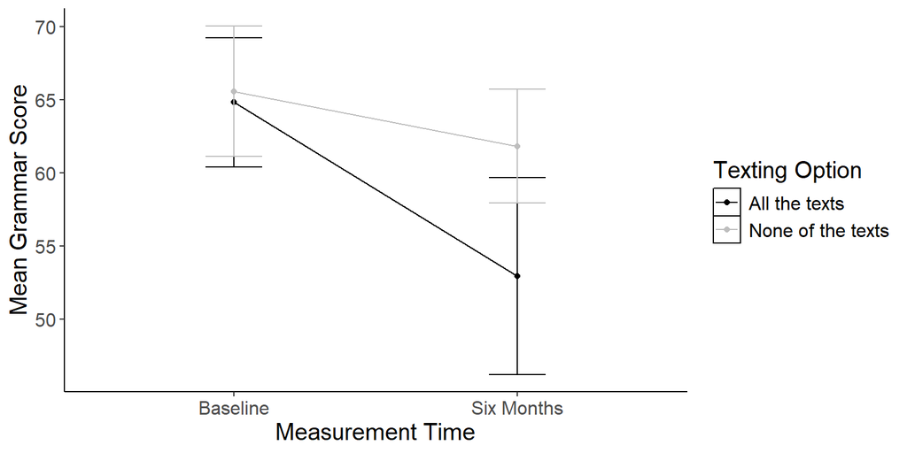

```r
textline <- ggplot(longtexting, aes(Time, Grammar_Score, color = Group))
textline +
  stat_summary(fun = mean,
               geom = "point") +
  stat_summary(fun = mean,
               geom = "line",
               aes(group = Group)) + #Group is the variable name
  stat_summary(fun.data = mean_cl_normal,
               geom = "errorbar",
               width = .2) +
  xlab("Measurement Time") +
  ylab("Mean Grammar Score") +
  cleanup +
  scale_color_manual(name = "Texting Option",
                     labels = c("All the texts", "None of the texts"),
                     values = c("Black", "Grey")) +
  scale_x_discrete(labels = c("Baseline", "Six Months"))
```

# Summary

- In this lecture, you have learned:
  - How to clean up your data for visualizations: `factor()` and `melt()`
  - Ideas for good visualizations (Tufte principles)
  - Histograms, scatterplots, bar charts, and line graphs
  - `ggplot2` structure and layered grammar of graphics
  - Error bars with confidence intervals
  - Custom themes for professional presentations

# Additional Resources

- ggplot2 documentation: https://ggplot2.tidyverse.org/
- R Graphics Cookbook: https://r-graphics.org/
- Modern alternatives: tidyr package for data reshaping
- Extension packages: patchwork (combining plots), plotly (interactive graphics)